# Sapronov-data-scientist-salary-eda

## Описание задачи

В качестве данных для анализа выбран датасет: https://www.kaggle.com/datasets/phuchuynguyen/salary-and-moredata-scientist-analyst-engineer

Зарплаты datascience направлений в разных странах

Обязательная часть:  
Вам необходимо провести базовый EDA выбранного набора данных.  
Требования к анализу:  
● построить не менее 4 визуализаций различных видов;  
● каждая визуализация должным образом оформлена и читается даже в отрыве от контекста;  
● по каждой визуализации необходимо написать вывод (какую гипотезу на ее основе можно выдвинуть?).

Дополнительная часть (необязательная)  
● построить дополнительно не менее 2 визуализаций (итого не менее 6);  
● в работе должны присутствовать следующие визуализации: boxplot, heatmap, scatter plot matrix;

## Импорт библиотек

```python
import pandas as pd
import numpy as np
import matplotlib.pyplot as plt
import seaborn as sns
```

## Загрузка датасета

```python
df = pd.read_csv('/kaggle/input/salary-and-moredata-scientist-analyst-engineer/data_survey.csv')
print(df.shape)
df = df.rename(columns={'ConvertedComp':'Salary'})
```

```
(33601, 14)
```

```python
df.dtypes
```

```
Year                                               int64
Hobbyist                                          object
Salary                                           float64
Country                                           object
EdLevel                                           object
Employment                                        object
JobSat                                           float64
OrgSize                                           object
UndergradMajor                                    object
YearsCodePro                                     float64
Data scientist or machine learning specialist      int64
Database administrator                             int64
Data or business analyst                         float64
Engineer, data                                   float64
dtype: object
```

## Редактирование датасета

Возьмем только ТОП-30 стран пол количеству наблюдений, за 2020 год

```python
top_30_countries = df[df['Year']==2020].Country.value_counts().head(30).index
df = df.loc[lambda x: x.Country.isin(top_30_countries) & (x.Year.isin([2020]))]
df.head()
```

|  | Year | Hobbyist | Salary | Country | EdLevel | Employment | JobSat | OrgSize | UndergradMajor | YearsCodePro | Data scientist or machine learning specialist | Database administrator | Data or business analyst | Engineer, data |
| --- | --- | --- | --- | --- | --- | --- | --- | --- | --- | --- | --- | --- | --- | --- |
| 25757 | 2020 | Yes | 32315.0 | United Kingdom | Master's degree | Employed full-time | 8.0 | 2 to 9 employees | Mathematics or statistics | 4.0 | 0 | 1 | 0.0 | 0.0 |
| 25758 | 2020 | Yes | 108576.0 | United Kingdom | Bachelor's degree | Independent contractor, freelancer, or self-em... | 8.0 | Just me - I am a freelancer, sole proprietor, ... | Computer science | 23.0 | 0 | 1 | 0.0 | 0.0 |
| 25759 | 2020 | Yes | 38778.0 | United Kingdom | Bachelor's degree | Employed full-time | 4.0 | NaN | Information systems | 2.0 | 0 | 1 | 1.0 | 0.0 |
| 25760 | 2020 | Yes | 77556.0 | United Kingdom | Some college/university study without earning ... | Employed full-time | 6.0 | 1,000 to 4,999 employees | Computer science | 3.0 | 1 | 0 | 1.0 | 0.0 |
| 25761 | 2020 | No | 55893.0 | Brazil | Master's degree | Employed full-time | 5.0 | 10 to 19 employees | Another engineering discipline | 6.0 | 0 | 0 | 1.0 | 0.0 |

## Первичный анализ данных

```python
for col in ['Year', 'Country', 'JobSat', 'UndergradMajor', 'Data scientist or machine learning specialist', 'Database administrator', 'Data or business analyst', 'Engineer, data']:
    print(df[col].value_counts())
    print('-----')
```

```
2020    6539
Name: Year, dtype: int64
-----
United States         1899
India                  544
Germany                532
United Kingdom         484
Canada                 283
Brazil                 263
France                 223
Australia              204
Netherlands            186
Spain                  185
Italy                  151
Poland                 144
Russian Federation     143
Sweden                 125
Switzerland            105
Mexico                  95
Czech Republic          88
South Africa            86
Pakistan                81
Turkey                  81
Belgium                 73
Israel                  71
Austria                 70
Ukraine                 64
Norway                  64
Denmark                 62
Iran                    61
Romania                 59
Greece                  58
Nigeria                 55
Name: Country, dtype: int64
-----
8.0    2299
6.0    2016
4.0    1072
5.0     681
2.0     464
```

[output cut: 17 more lines]

```
1    2090
Name: Data scientist or machine learning specialist, dtype: int64
-----
0    3482
1    3057
Name: Database administrator, dtype: int64
-----
0.0    4528
1.0    2011
Name: Data or business analyst, dtype: int64
-----
0.0    4489
1.0    2050
Name: Engineer, data, dtype: int64
-----
```

## 1. Histogram

```python
columns_to_plot = ['Salary', 'YearsCodePro', 'JobSat']
columns_dict = {'Salary': 'Зарплата, у.е.',
                 'YearsCodePro': 'Опыт работы, лет',
                 'JobSat': 'Рейтинг удовлетворенности работой',
                 'Country': 'Страны',
                 'part_of_the_world': 'Части Света',
                 'Count_specialization': 'Кол-во направлений работы'}
```

```python
## Числовая интерпретация гистограммы
df[columns_to_plot].describe()
```

|  | Salary | YearsCodePro | JobSat |
| --- | --- | --- | --- |
| count | 6539.000000 | 6513.000000 | 6532.000000 |
| mean | 69169.628995 | 9.315983 | 5.987293 |
| std | 52547.929835 | 7.831727 | 1.818092 |
| min | 1.000000 | 1.000000 | 2.000000 |
| 25% | 29191.500000 | 3.000000 | 5.000000 |
| 50% | 58368.000000 | 7.000000 | 6.000000 |
| 75% | 96945.000000 | 13.000000 | 8.000000 |
| max | 298356.000000 | 30.000000 | 8.000000 |

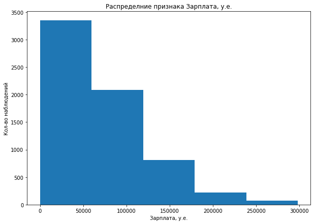

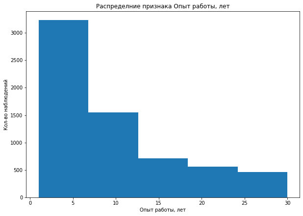

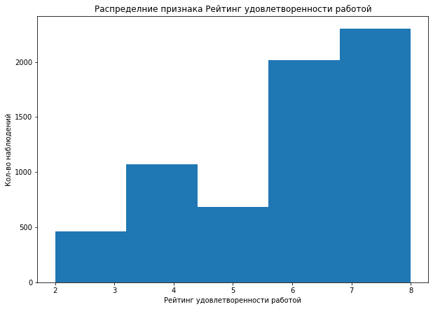

```python
for item in columns_to_plot:
    df[item].plot.hist(title='Распределние признака ' + columns_dict[item], figsize=(10,7), bins=5)
    plt.xlabel(columns_dict[item])
    plt.ylabel('Кол-во наблюдений')
    plt.show()
```

Гипотезы:  
1) Работники с большим опытом имеют более высокую зарплату. Сравнить сегменты с шагом в 5 лет (подобрать интервал).  
2) Работники с большей зарплатой более удовлетворены работой.  
3) Существует взаимосвязь между опытом работника и его удовлетворенностью работой.

## 2. BarPlot

### Построен только для направления 'Data scientist or machine learning specialist'

```python
df['part_of_the_world'] = \
df['Country'].map({'Israel': 'Asia',
                                    'United States': 'North_America',
                                    'Switzerland': 'Europe',
                                    'Denmark': 'Europe',
                                    'Norway': 'Europe',
                                    'Australia': 'Australia',
                                    'Canada': 'North_America',
                                    'Germany': 'Europe',
                                    'United Kingdom': 'Europe',
                                    'Netherlands': 'Europe',
                                    'France': 'Europe',
                                    'Sweden': 'Europe',
                                    'Belgium': 'Europe',
                                    'Austria': 'Europe',
                                    'Italy': 'Europe',
                                    'South Africa': 'Africa',
                                    'Czech Republic': 'Europe',
                                    'Romania': 'Europe',
                                    'Spain': 'Europe',
                                    'Poland': 'Europe',
                                    'Russian Federation': 'Asia',
                                    'Ukraine': 'Europe',
                                    'Mexico': 'North_America',
                                    'Greece': 'Europe',
                                    'Brazil': 'South_America',
                                    'Turkey': 'Europe',
                                    'Iran': 'Europe',
                                    'India': 'Asia',
                                    'Pakistan': 'Asia',
                                    'Nigeria': 'Africa'})
```

```python
def plot_barplot(df, speciality_name, group_name):

    top_salary = df[(df['Data scientist or machine learning specialist']==1)]\
            .groupby(group_name).Salary.median().sort_values(ascending=False).reset_index()

    plt.figure(figsize = (12,10))

    ax = sns.barplot(x='Salary', y=group_name, data=top_salary)
    plt.title("Медианная зарплата в 2020 году специалистов Data Science", fontsize = 16, pad=10)
    ax.set_xlabel("Зарплата, у.е.", fontsize=14, labelpad=5)
    ax.set_ylabel("")
    ax.tick_params(labelsize=12)

    plt.show()
```

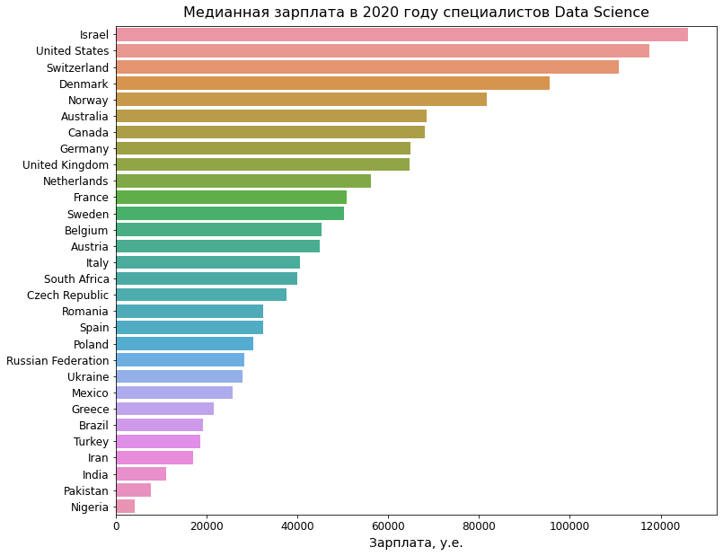

```python
plot_barplot(df, 'Data scientist or machine learning specialist', 'Country')
```

Выводы по графику:  
1) Только 9 стран имеют медиану выше 60000 у.е.  
2) Разбос медиан между 1ой и 30ой страной различается в 30 раз. Уровень зарплат в разных странах различается.

Гипотезы:  
1) Есть зависимость между медианной зарплатой в стране и ее географическому положению (материку, части света)  
2) Медианная зарплата в стране коррелирует с некоторым ее показателем (численность населения, уровень ВВП)

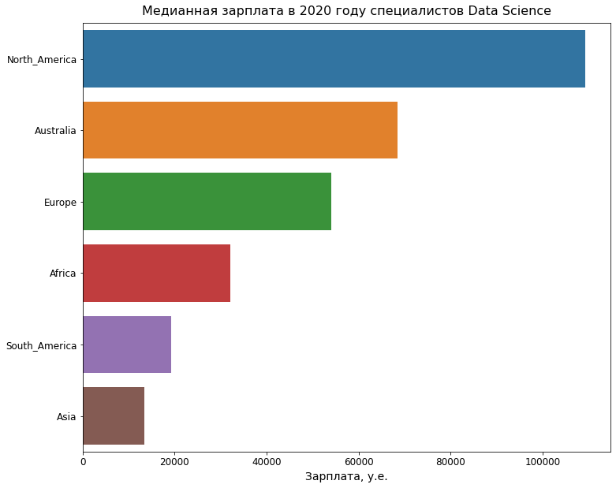

```python
plot_barplot(df, 'Data scientist or machine learning specialist', 'part_of_the_world')
```

Выводы по графику:  
1) Наибольшие зарплаты 'Data scientist or machine learning specialist' в Северной Америке, наименьшие - в Азии.  
2) Некоторые страны (например, Израиль в Азии) не соответсвтвуют своей Части Света по медиане зарплаты

Гипотезы:  
1) Медианная зарплата в стране коррелирует с некоторым ее показателем (численность населения, уровень ВВП)

## 3. Boxplot на примере Russian Federation

#### Рассмотрим зависимость зарплаты от направления работы сотрудников

Возьмем определенную страну, так как в разных странах могут быть различные значения зарплат в зависимости от направлений работы

```python
df_for_boxplot = df[df['Country']=='Russian Federation']\
                 [['Salary', 'Data scientist or machine learning specialist', 'Database administrator', 'Data or business analyst', 'Engineer, data']]
```

```python
# Удалим выброс, у работника максимальная зарплата по всем направлениям
df_for_boxplot = df_for_boxplot.loc[lambda x: x['Salary']<120000].loc[lambda x: x['Salary']>12]
```

```python
# Если сотрудник работает в определенном направлении, то добавим в данный столбец его Salary. Иначе Nan
for col in ['Data scientist or machine learning specialist', 'Database administrator', 'Data or business analyst', 'Engineer, data']:
    df_for_boxplot[col] = (df_for_boxplot[col] * df_for_boxplot['Salary']).map(lambda x: x if x>0 else np.nan)
```

```python
df_for_boxplot.describe()
```

|  | Salary | Data scientist or machine learning specialist | Database administrator | Data or business analyst | Engineer, data |
| --- | --- | --- | --- | --- | --- |
| count | 141.000000 | 48.000000 | 59.000000 | 44.000000 | 43.000000 |
| mean | 29135.078014 | 31309.541667 | 26558.203390 | 30656.113636 | 33759.348837 |
| std | 16756.100141 | 16850.940864 | 15883.321905 | 16953.044154 | 16784.832927 |
| min | 3780.000000 | 6600.000000 | 3780.000000 | 6600.000000 | 7548.000000 |
| 25% | 15660.000000 | 20760.000000 | 15096.000000 | 18639.000000 | 19818.000000 |
| 50% | 26160.000000 | 28254.000000 | 23591.000000 | 27786.000000 | 32088.000000 |
| 75% | 37752.000000 | 36330.000000 | 37476.000000 | 39855.000000 | 47172.000000 |
| max | 94368.000000 | 94368.000000 | 67944.000000 | 75492.000000 | 75492.000000 |

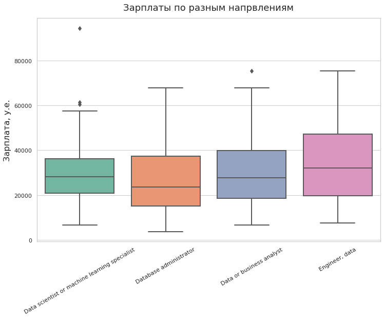

```python
plt.figure(figsize = (12,8))

# Plot
ax= sns.boxplot(data=df_for_boxplot.drop('Salary', axis=1), linewidth=2,fliersize=6, palette="Set2")
sns.set_theme(style='whitegrid')

plt.title('Зарплаты по разным напрвлениям', fontsize = 18, pad=15)
ax.set_xlabel("")
ax.set_ylabel("Зарплата, у.е.", fontsize=16, labelpad=5)
plt.setp(ax.get_xticklabels(), rotation=30)

plt.show()
```

Выводы по графику:  
1) Медианы зарплат в России по каждому из 4 направлений находятся в диапазоне 23-33 тыс. у.е.  
2) Наибольший разброс зарплат между 25% и 75% квартилем у направления 'Engineer,data', наименьший - у 'Data scientist or machine learning specialist'  
3) По квартильным значениям наибольшие зарплаты в направлении 'Engineer,data', наибольшее значение 94368 у.е. у представителя 'Data scientist or machine learning specialist'

Гипотезы:  
1) В направлении 'Engineer,data' средняя зарплата выше, чем в других направлениях. Проверить статистическую значимость  
2) Зависимость между направлением работы и зарплатой отсутствует

#### Рассмотрим зависимость зарплаты в сфере 'Engineer, data' от опыта работы сотрудников

Разделим опыт работы равномерно на 4 части

```python
df_for_boxplot_2 = df[(df['Country']=='Russian Federation') & (df['Engineer, data']==1)]\
                     [['Salary', 'YearsCodePro', 'Engineer, data']]
df_for_boxplot_2['YearsCodePro_segment'] = pd.qcut(df_for_boxplot_2.YearsCodePro, q=4)
```

```python
df_for_boxplot_2 = df_for_boxplot_2[['YearsCodePro_segment', 'Salary']].groupby('YearsCodePro_segment')['Salary']\
                                                    .apply(lambda df: df.reset_index(drop=True))\
                                                    .unstack(0)
```

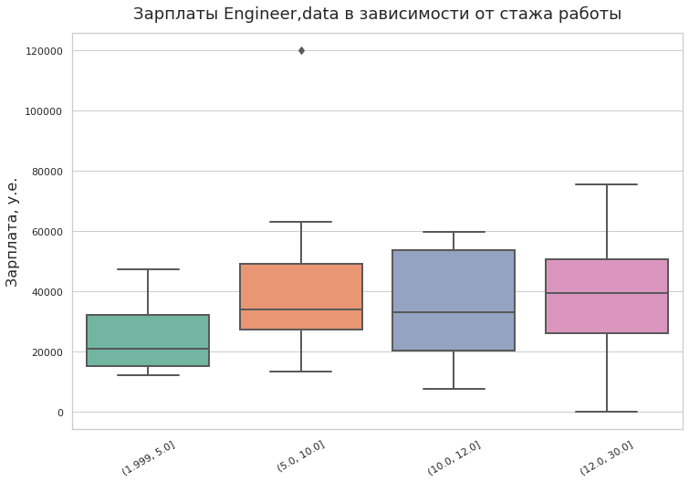

```python
plt.figure(figsize = (12,8))

ax= sns.boxplot(data=df_for_boxplot_2, linewidth=2,fliersize=6, palette="Set2")
sns.set_theme(style='whitegrid')

plt.title('Зарплаты Engineer,data в зависимости от стажа работы', fontsize = 18, pad=15)
ax.set_xlabel("")
ax.set_ylabel("Зарплата, у.е.", fontsize=16, labelpad=5)
plt.setp(ax.get_xticklabels(), rotation=30)
# Show the plot
plt.show()
```

Гипотезы:  
1) Существует зависимость между опытом работы и зарплатой сотрудника

## Дальнейшие графики строятся на примере США

```python
#your_country = 'Russian Federation'
your_country = 'United States'
```

## 4. Heatmap (correlation matrix)

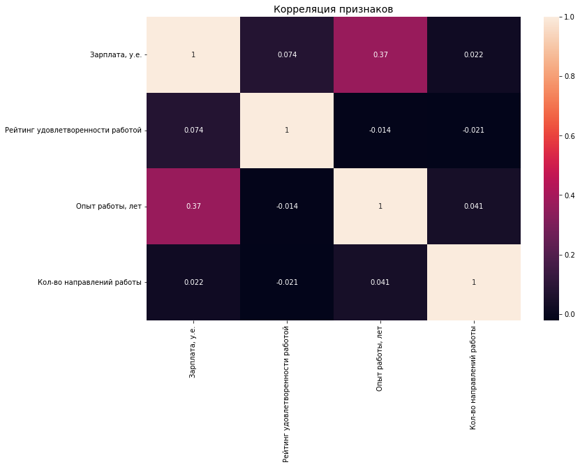

```python
plt.figure(figsize = (12,8))
sns.heatmap(df[df['Country']==your_country].assign(Count_specialization=lambda x: x['Data scientist or machine learning specialist'] +
                                                     x['Database administrator'] + x['Data or business analyst'] +
                                                     x['Engineer, data'])[['Salary', 'JobSat', 'YearsCodePro', 'Count_specialization']]\
            .rename(columns=columns_dict)\
            .corr(), annot=True).set_title('Корреляция признаков',size=14)
plt.show()
```

Выводы по графику:  
1) Есть незначительная положительная корреляция между опытом работы и заработной платой сотрудников  
2) Суммарное кол-во направлений сотрудника не влияет на другие показатели

Гипотезы:  
1) Опыт работы влияет на уровень зарплаты (проверить положительную корелляцию на статистическую значимость)  
2) Кол-во охватываемых сотрудником направлений не влияет на его зарплату

## 5. Scatter Plot

```python
#your_country = 'Russian Federation'
your_country = 'United States'
```

[figure not shown]

```python
plt.figure(figsize=(12,8))
sns.scatterplot(data=df[df['Country']==your_country], x="YearsCodePro", y="Salary")
plt.title('Зависимость между уровнем зарплаты и степенью удовлетворенности работой в 2020 году', fontsize = 15)
plt.xlabel('Уровень удовлетворенности работой',size=14)
plt.ylabel('Зарплата у.е.',size=14)
plt.show()
```

```python
df[df['Country']==your_country].loc[lambda x: x.YearsCodePro==30].Salary.describe()
```

```
count       120.00000
mean     139618.60000
std       55112.64942
min       30000.00000
25%      100000.00000
50%      130000.00000
75%      176250.00000
max      252000.00000
Name: Salary, dtype: float64
```

Выводы по графику:  
1) Люди с определенным стажем работы имеют свои диапазоны зарплат. Например, у сотрудников с 30 летним стажем зарплата находится в диапазоне от 100 до 175 тысяч у.е.  
2) Сотрудников с опытом менее 10 лет, больше тех, кто трудится более 10 лет

Гипотезы:  
1) Зарплата зависит от другого показателя (например, уровня квалификации сотрудника)

## Scatter Plot Matrix

```python
your_country = 'United States'
```

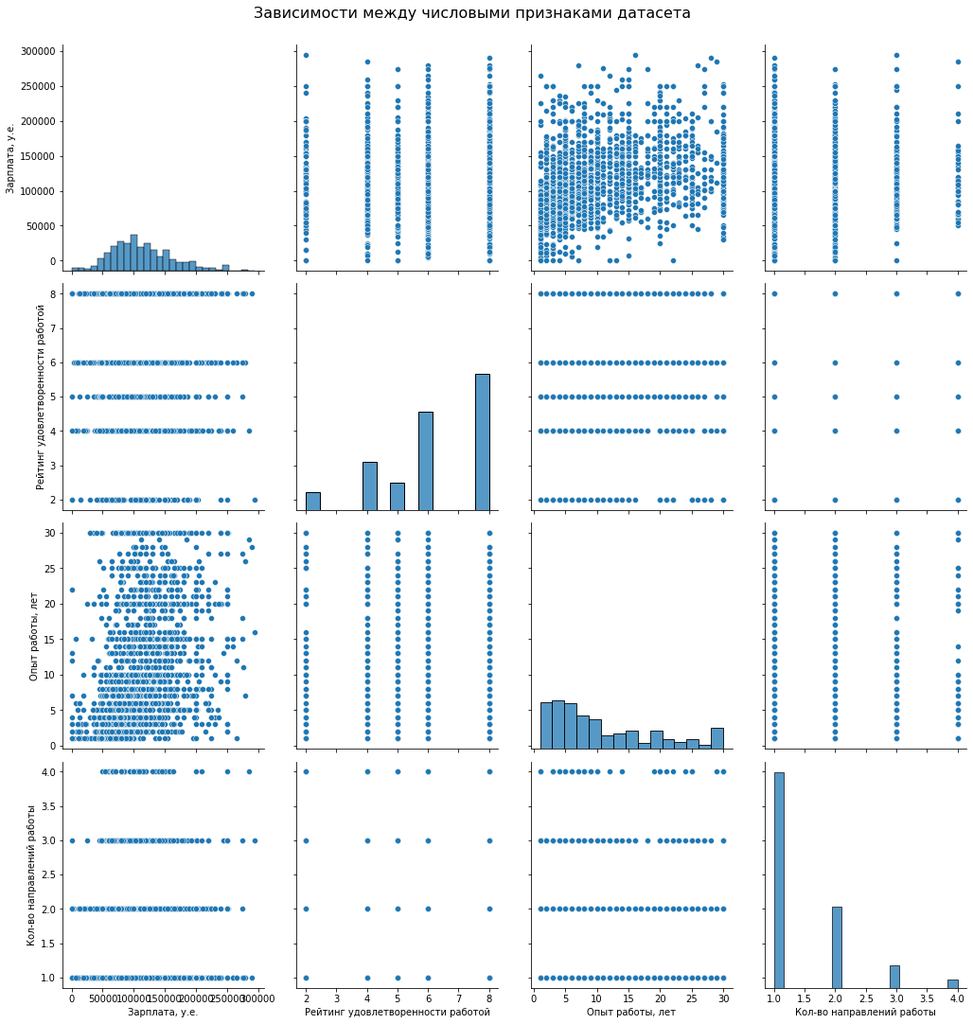

```python
g = sns.pairplot(df[df['Country']==your_country].assign(Count_specialization=lambda x: x['Data scientist or machine learning specialist'] +
                                                     x['Database administrator'] + x['Data or business analyst'] +
                                                     x['Engineer, data'])[['Salary', 'JobSat', 'YearsCodePro', 'Count_specialization']]\
                                                     .rename(columns=columns_dict))
g.fig.set_figheight(15)
g.fig.set_figwidth(15)
g.fig.suptitle("Зависимости между числовыми признаками датасета", fontsize = 16, y=1.02)
```

Выводы по графику:  
1) Распределение опыта работы в США отличается от ообщего распределения признака по всем странам (графики 1.Histogram)  
2) Наиболее встречаема только одна специализация в работе сотрудника  
3) Есть незначительная положительная корреляция между опытом работы и заработной платой сотрудников

Гипотезы такие же, как на 4.HeatMap диаграмме

## 7. scatter_geo

```python
import plotly.express as px

fig=px.scatter_geo(df.groupby('Country').Salary.median().reset_index().assign(Salary=lambda x: round(x.Salary,0)),
                   locationmode='country names',locations='Country',color='Salary'
                  ,hover_data=['Country','Salary'],size='Salary'
                  ,projection='natural earth',size_max=25,template='plotly_dark')
fig.show()
```

[interactive chart not shown]

Выводы по графику:  
1) Наибольшая медиана зарплат в представленных странах Северной Америки, Австралии и некоторых странах Европы.  
2) Наименьшие медиана зарплат в представленных странах Азии и Южной Америки.

Гипотезы:  
1) Медианная зарплата в стране коррелирует с некоторым ее показателем (численность населения, уровень ВВП).